# MetNet - workshop Toulouse

Thomas Naake

9/23/2021

# 1 Prepare the environment and load the data

Load, if not done yet, the `dplyr` and `igraph` package first.

```r
library(MetNet)

## print the version of MetNet
package.version("MetNet")
```

```
## [1] "1.11.4"
```

data requirements: - $m~\times~n$ matrix, where columns denote the different samples $n$ and where $m$ features are present, - proper data normalization and transformation, - information on m/z values has to be stored in a vector of length $\vert m \vert$ in the column `"mz"`, - optionally, information on retention time in the column `"rt"`.

```r
peaklist_vals <- openxlsx::read.xlsx(
    xlsxFile = "20210219_CelegansPathogenMicrobiome_RP_pos_Cluster_char.xlsx",
    sheet = "Stage 3", startRow = 1, colNames = TRUE, rowNames = TRUE,
    skipEmptyRows = FALSE, skipEmptyCols = FALSE, na.strings = "")

## remove the superfluous columns in peaklist_vals (only keep samples)
cols_vals <- which(colnames(peaklist_vals) == "QC_cond_2-A,2_10_29503")
peaklist_vals <- peaklist_vals[, 1:cols_vals]

## extract meta data and intensities from peaklist_vals
peaklist_meta <- t(peaklist_vals[1:10, ]) %>%
    as.data.frame()
colnames(peaklist_meta) <- make.names(colnames(peaklist_meta))
peaklist_vals <- peaklist_vals[11:nrow(peaklist_vals), ] %>%
    as.matrix()
mode(peaklist_vals) <- "numeric"

## add the information on the features (mz, retention time)
peaklist_feat <- read.table(file = "Experimental_Data.csv", sep = ",", header = TRUE)
rownames(peaklist_feat) <- peaklist_feat[, "Name"]
```

## 1.1 Quality check with MatrixQCvis

```r
## create SummarizedExperiment object
library(SummarizedExperiment)
se <- SummarizedExperiment(assays = peaklist_vals, rowData = peaklist_feat,
                     colData = peaklist_meta)

library(MatrixQCvis)
## shinyQC(se)
```

Do the normalization, batch correction, transformation after removing the blank.

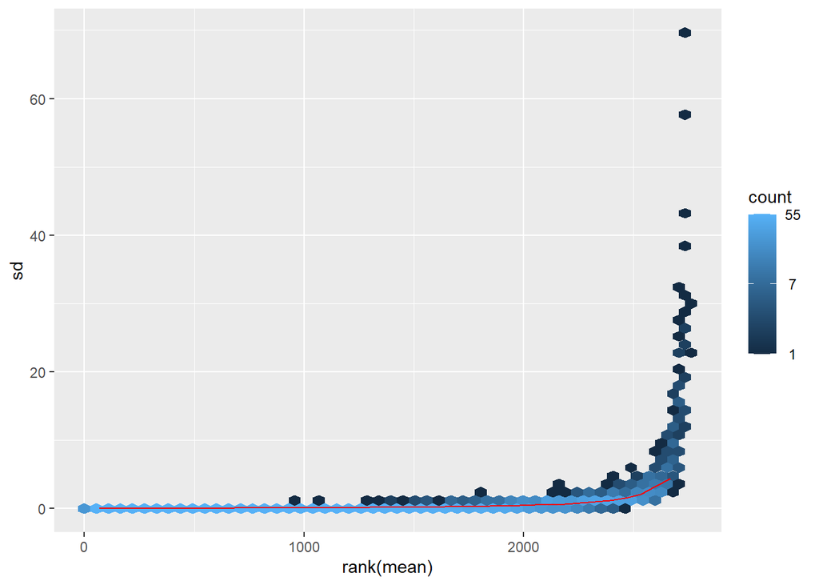

```r
se <- se[, !grepl(colnames(se), pattern = "blank")]

## remove low-abundant features from se (remove the features with more than
## 30 missing values)
se <- se[!apply(assay(se), 1, function(x) sum(is.na(x))) > 30, ]

## normalization
peaklist_vals <- assay(se) %>%
    normalizeAssay(., method = "quantile division", probs = 0.75)

## batch correction
peaklist_vals_b <- peaklist_vals %>%
    imputeAssay(., method = "MinDet") %>%
    sva::ComBat(., batch = se$Batch)
peaklist_vals_b[is.na(peaklist_vals)] <- NA

## check the variance homogeneity and perform vsn transformation
vsn::meanSdPlot(peaklist_vals_b)
```

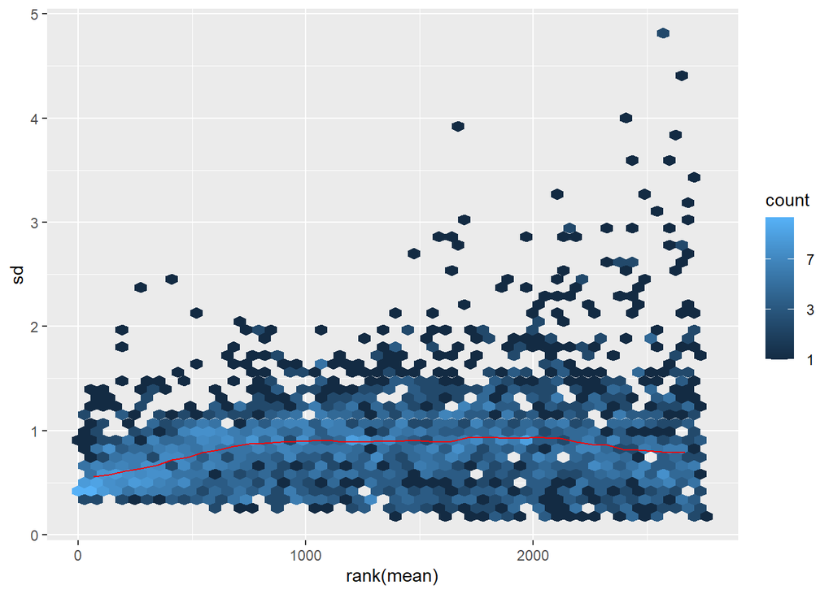

```r
peaklist_vals <- vsn::vsn2(peaklist_vals_b)
vsn::meanSdPlot(peaklist_vals)
```

```r
## create a peaklist object that contains information on the mz and rt and
## the transformed intensities
peaklist <- data.frame(mz = rowData(se)[, "mz"], rt = rowData(se)[, "RT"],
                  peaklist_vals@hx)

## assign new rownames to peaklist (composed of mz and RT information)
rn <- paste0("m", round(peaklist[, "mz"], 3), "_", round(peaklist[, "rt"], 2))
peaklist <- peaklist[!duplicated(rn), ]
rownames(peaklist) <- rn[!duplicated(rn)]

## remove the columns with the QCs
peaklist <- peaklist[, !grepl(colnames(peaklist), pattern = "QC_")]
```

# 2 Structural AdjacencyMatrix object

```r
transformations <- rbind(
    c("Hydroxylation (-H)", "O", 15.9949146221, "-"),
    c("Malonyl group (-H2O)", "C3H2O3", 86.0003939305, "+"),
    c("Monosaccharide (-H2O)", "C6H10O5", 162.0528234315, "-"))

## convert to data frame
transformations <- data.frame(
    group = transformations[, 1],
    formula = transformations[, 2],
    mass = as.numeric(transformations[, 3]),
    rt = transformations[, 4])
```

Create the structural adjacency matrix by running the function `structural`.

```r
struct_adj <- structural(x = peaklist, transformation = transformations,
                         ppm = 10)
```

Print information on the object `struct_adj`.

```r
struct_adj
```

```
## class: AdjacencyMatrix
## dim: 2733 2733
## type(1): structural
## directed(1): FALSE
## thresholded(1): FALSE
## assay(3): binary transformation mass_difference
## rownames(2733): m70.982_0.54 m86.382_0.95 ... m1083.64_5.34
##   m1083.639_5.43
## colnames(2733): m70.982_0.54 m86.382_0.95 ... m1083.64_5.34
##   m1083.639_5.43
```

```r
## get information on type, directed, thresholded
struct_adj@type
```

```
## [1] "structural"
```

```r
struct_adj@directed
```

```
## [1] FALSE
```

```r
struct_adj@thresholded
```

```
## [1] FALSE
```

```r
## show the stored adjacency matrices
assay(struct_adj, "binary")[26:28, 614:616]
```

```
##              m241.068_3.5 m241.155_0.69 m242.286_5.24
## m79.017_0.52            1             0             0
## m79.017_0.91            1             0             0
## m80.037_0.54            0             0             0
```

```r
assay(struct_adj, "transformation")[26:28, 614:616]
```

```
##              m241.068_3.5            m241.155_0.69 m242.286_5.24
## m79.017_0.52 "Monosaccharide (-H2O)" ""            ""
## m79.017_0.91 "Monosaccharide (-H2O)" ""            ""
## m80.037_0.54 ""                      ""            ""
```

```r
assay(struct_adj, "mass_difference")[26:28, 614:616]
```

```
##              m241.068_3.5     m241.155_0.69 m242.286_5.24
## m79.017_0.52 "162.0528234315" ""            ""
## m79.017_0.91 "162.0528234315" ""            ""
## m80.037_0.54 ""               ""            ""
```

```r
## how many edges are there in total
assay(struct_adj, "binary") %>%
    table()
```

```
## .
##       0       1
## 7465983    3306
```

## 2.1 Refining the structural AdjacencyMatrix object (rtCorrection)

Use the retention time information to remove false positive associations by accounting for the polarity change. Use the function `rtCorrection`. The slot will change from `FALSE` (`struct_adj`) to `TRUE` (`struct_adj_rt`).

```r
struct_adj_rt <- rtCorrection(am = struct_adj, x = peaklist,
                              transformation = transformations)
struct_adj
```

```
## class: AdjacencyMatrix
## dim: 2733 2733
## type(1): structural
## directed(1): FALSE
## thresholded(1): FALSE
## assay(3): binary transformation mass_difference
## rownames(2733): m70.982_0.54 m86.382_0.95 ... m1083.64_5.34
##   m1083.639_5.43
## colnames(2733): m70.982_0.54 m86.382_0.95 ... m1083.64_5.34
##   m1083.639_5.43
```

```r
struct_adj_rt
```

```
## class: AdjacencyMatrix
## dim: 2733 2733
## type(1): structural
## directed(1): FALSE
## thresholded(1): TRUE
## assay(3): binary transformation mass_difference
## rownames(2733): m70.982_0.54 m86.382_0.95 ... m1083.64_5.34
##   m1083.639_5.43
## colnames(2733): m70.982_0.54 m86.382_0.95 ... m1083.64_5.34
##   m1083.639_5.43
```

```r
## how many edges are there in total
assay(struct_adj_rt, "binary") %>%
    table()
```

```
## .
##       0       1
## 7467451    1838
```

Get information which features link to each other

```r
## show the information in struct_adj_rt in tabular format
struct_df <- as.data.frame(struct_adj_rt)
filter(struct_df, binary == 1) %>%
    head()
```

```
##             Row           Col binary     transformation mass_difference
## 1   m84.082_1.1    m100.077_1      1 Hydroxylation (-H)   15.9949146221
## 2  m101.022_0.9   m85.028_6.9      1 Hydroxylation (-H)   15.9949146221
## 3 m105.056_2.75  m89.062_3.49      1 Hydroxylation (-H)   15.9949146221
## 4 m116.072_0.71    m100.077_1      1 Hydroxylation (-H)   15.9949146221
## 5 m116.072_0.71 m100.076_4.86      1 Hydroxylation (-H)   15.9949146221
## 6 m117.092_2.79 m101.097_3.49      1 Hydroxylation (-H)   15.9949146221
```

Mass-difference distribution of the data. The number of determined mass differences can be displayed by using the `mz_vis` function

```r
mz_sum <- mz_summary(struct_adj_rt)
mz_sum
```

[output not shown]

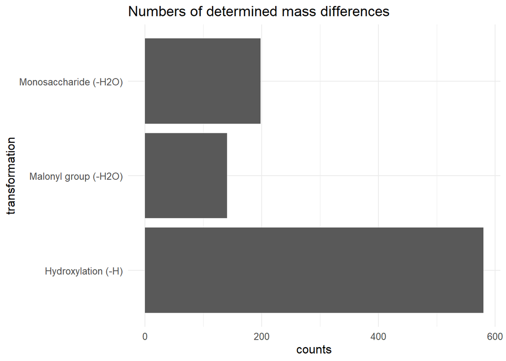

```r
## visualize the numbers
mz_vis(mz_sum)
```

## 2.2 Creating a directed structural AdjacencyMatrix object

```r
## undirected
struct_adj_undir <- structural(x = peaklist,
        transformation = transformations, ppm = 10, directed = FALSE) %>%
    rtCorrection(am = ., x = peaklist, transformation = transformations)
struct_adj_undir
```

```
## class: AdjacencyMatrix
## dim: 2733 2733
## type(1): structural
## directed(1): FALSE
## thresholded(1): TRUE
## assay(3): binary transformation mass_difference
## rownames(2733): m70.982_0.54 m86.382_0.95 ... m1083.64_5.34
##   m1083.639_5.43
## colnames(2733): m70.982_0.54 m86.382_0.95 ... m1083.64_5.34
##   m1083.639_5.43
```

```r
## directed
struct_adj_dir <- structural(x = peaklist,
        transformation = transformations, ppm = 10, directed = TRUE) %>%
    rtCorrection(am = ., x = peaklist, transformation = transformations)
struct_adj_dir
```

```
## class: AdjacencyMatrix
## dim: 2733 2733
## type(1): structural
## directed(1): TRUE
## thresholded(1): TRUE
## assay(3): binary transformation mass_difference
## rownames(2733): m70.982_0.54 m86.382_0.95 ... m1083.64_5.34
##   m1083.639_5.43
## colnames(2733): m70.982_0.54 m86.382_0.95 ... m1083.64_5.34
##   m1083.639_5.43
```

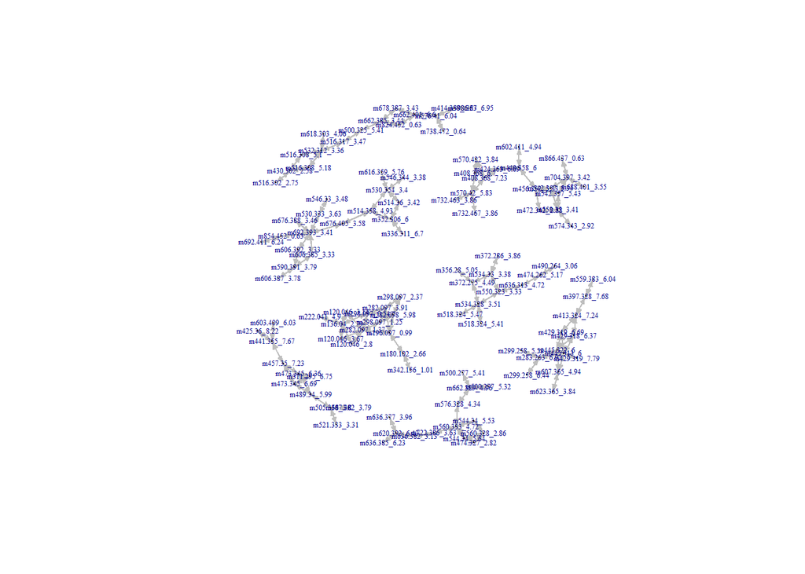

```r
## plot the undirected matrix
adj <- assay(struct_adj_undir, "binary")
g_undirected_comp <- graph_from_adjacency_matrix(adjmatrix = adj,
        mode = "directed", weighted = NULL) %>%
    components()
inds <- g_undirected_comp$membership %in% which(g_undirected_comp$csize > 10)

## create a graph from the cut adjacency matrix and plot the undirected graph
g_undirected <- graph_from_adjacency_matrix(adj[inds, inds], mode = "directed")
plot(g_undirected, edge.width = 1, edge.arrow.size = 0.3,
     vertex.label.cex = 0.4, vertex.size = 0.5, edge.color = "grey")
```

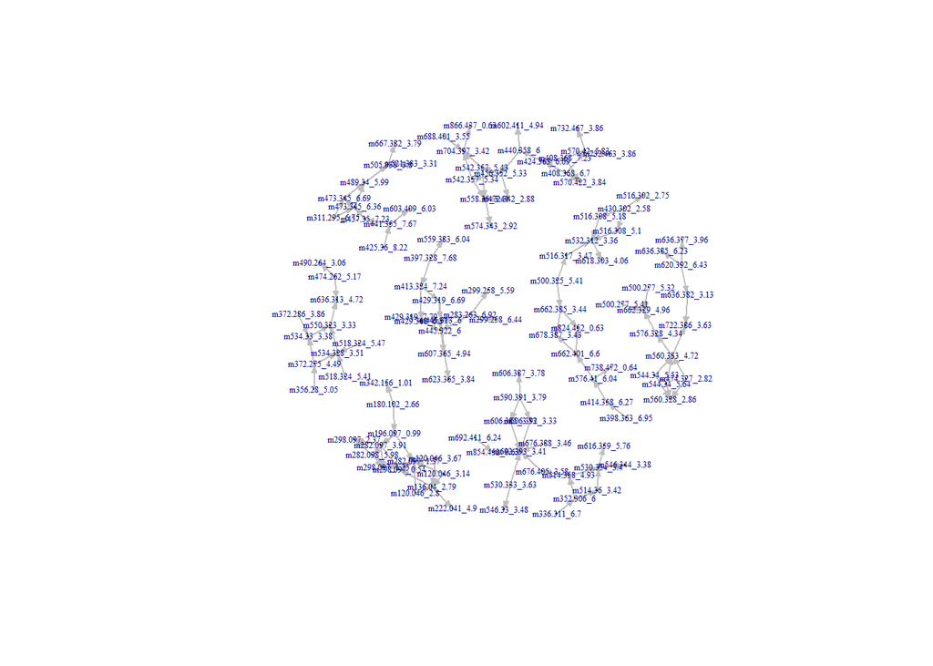

```r
## plot the directed matrix
adj <- assay(struct_adj_dir, "binary")
g_directed_comp <- graph_from_adjacency_matrix(adjmatrix = adj,
          mode = "directed", weighted = NULL) %>%
      components()
inds <- g_directed_comp$membership %in% which(g_directed_comp$csize > 10)

## create a graph from the cut adjacency matrix and plot the directed graph
g_directed <- graph_from_adjacency_matrix(adj[inds, inds], mode = "directed")
plot(g_directed, edge.width = 1, edge.arrow.size = 0.3,
     vertex.label.cex = 0.4, vertex.size = 0.5, edge.color = "grey")
```

# 3 Statistical AdjacencyMatrix object

Create the adjacency matrix based on Pearson and Spearman correlation.

```r
## the function takes as input a numerical matrix with
## (transformed) intensities
stat_adj <- select(peaklist, -c("mz", "rt")) %>%
    as.matrix() %>%
    statistical(., model = c("pearson", "spearman"), p.adjust = "BH")
```

```
## [1] "pearson finished."
## [1] "spearman finished."
```

```r
## print information on stat_adj
stat_adj
```

```
## class: AdjacencyMatrix
## dim: 2733 2733
## type(1): statistical
## directed(1): FALSE
## thresholded(1): FALSE
## assay(4): pearson_coef pearson_pvalue spearman_coef spearman_pvalue
## rownames(2733): m70.982_0.54 m86.382_0.95 ... m1083.64_5.34
##   m1083.639_5.43
## colnames(2733): m70.982_0.54 m86.382_0.95 ... m1083.64_5.34
##   m1083.639_5.43
```

Return the edges with Pearson correlation coefficients $> 0.6$ and Spearman correlation coefficients $> 0.6$ and adjusted p-values $< 0.05$.

```r
## define the filter criteria
args_thr <- list(
    filter = "abs(pearson_coef) > 0.6 & abs(spearman_coef) > 0.6 & pearson_pvalue < 0.05 & spearman_pvalue < 0.05")

## apply the filter criteria on stat_adj and add an assay containing
## binary information
stat_adj_thr <- threshold(am = stat_adj, type = "threshold",
                          args = args_thr)
stat_adj_thr
```

```
## class: AdjacencyMatrix
## dim: 2733 2733
## type(1): statistical
## directed(1): FALSE
## thresholded(1): TRUE
## assay(5): pearson_coef pearson_pvalue spearman_coef spearman_pvalue
##   consensus
## rownames(2733): m70.982_0.54 m86.382_0.95 ... m1083.64_5.34
##   m1083.639_5.43
## colnames(2733): m70.982_0.54 m86.382_0.95 ... m1083.64_5.34
##   m1083.639_5.43
```

```r
## show the information in stat_adj_thr in tabular format
stat_adj_thr_df <- as.data.frame(stat_adj_thr)
head(stat_adj_thr_df)
```

```
##                Row          Col pearson_coef pearson_pvalue spearman_coef
## 2734  m86.382_0.95 m70.982_0.54   0.15371283   0.3160540279    0.19952610
## 5467  m86.422_0.95 m70.982_0.54   0.02977384   0.8828578339    0.01895604
## 5468  m86.422_0.95 m86.382_0.95   0.90787630   0.0000000000    0.88844588
## 8200 m128.045_0.54 m70.982_0.54   0.81427416   0.0000000000    0.84522882
## 8201 m128.045_0.54 m86.382_0.95   0.45225356   0.0002790765    0.43405405
## 8202 m128.045_0.54 m86.422_0.95   0.29521950   0.0494118179    0.20814132
##      spearman_pvalue consensus
## 2734     0.169581931         0
## 5467     0.925544971         0
## 5468     0.000000000         1
## 8200     0.000000000         1
## 8201     0.000531432         0
## 8202     0.189628004         0
```

# 4 Combine the structural and statistical AdjacencyMatrix object

```r
comb_adj <- combine(am_structural = struct_adj_rt,
                    am_statistical = stat_adj_thr)

## print information on stat_adj
comb_adj
```

```
## class: AdjacencyMatrix
## dim: 2733 2733
## type(1): combine
## directed(1): FALSE
## thresholded(1): TRUE
## assay(11): pearson_coef pearson_pvalue ... combine_transformation
##   combine_mass_difference
## rownames(2733): m70.982_0.54 m86.382_0.95 ... m1083.64_5.34
##   m1083.639_5.43
## colnames(2733): m70.982_0.54 m86.382_0.95 ... m1083.64_5.34
##   m1083.639_5.43
```

```r
## show the information in comb_adj in tabular format
comb_adj_df <- as.data.frame(comb_adj)
filter(comb_adj_df, combine_binary == 1) %>%
    head()
```

```
##             Row           Col pearson_coef pearson_pvalue spearman_coef
## 1 m136.077_0.86 m120.082_1.65    0.9110228   0.000000e+00     0.8597667
## 2 m159.092_2.42 m245.096_2.81    0.6268617   2.123303e-10     0.6454965
## 3 m164.076_0.99 m250.077_1.15    0.6456148   3.597135e-11     0.6376967
## 4 m182.082_2.87 m166.087_3.22    0.7163616   3.955874e-12     0.7705940
## 5 m182.082_0.86 m166.087_3.22    0.6907774   7.087295e-13     0.7182865
## 6 m182.082_0.86 m166.087_0.99    0.9360955   0.000000e+00     0.9106213
##   spearman_pvalue consensus binary       transformation mass_difference
## 1    0.000000e+00         1      1   Hydroxylation (-H)   15.9949146221
## 2    3.552932e-11         1      1 Malonyl group (-H2O)   86.0003939305
## 3    7.553641e-11         1      1 Malonyl group (-H2O)   86.0003939305
## 4    0.000000e+00         1      1   Hydroxylation (-H)   15.9949146221
## 5    2.072334e-14         1      1   Hydroxylation (-H)   15.9949146221
## 6    0.000000e+00         1      1   Hydroxylation (-H)   15.9949146221
##   combine_binary combine_transformation combine_mass_difference
## 1              1     Hydroxylation (-H)           15.9949146221
## 2              1   Malonyl group (-H2O)           86.0003939305
## 3              1   Malonyl group (-H2O)           86.0003939305
## 4              1     Hydroxylation (-H)           15.9949146221
## 5              1     Hydroxylation (-H)           15.9949146221
## 6              1     Hydroxylation (-H)           15.9949146221
```

## 4.1 Visualization

Visualize the final adjacency matrix that combines the information from both structural and statistical information.

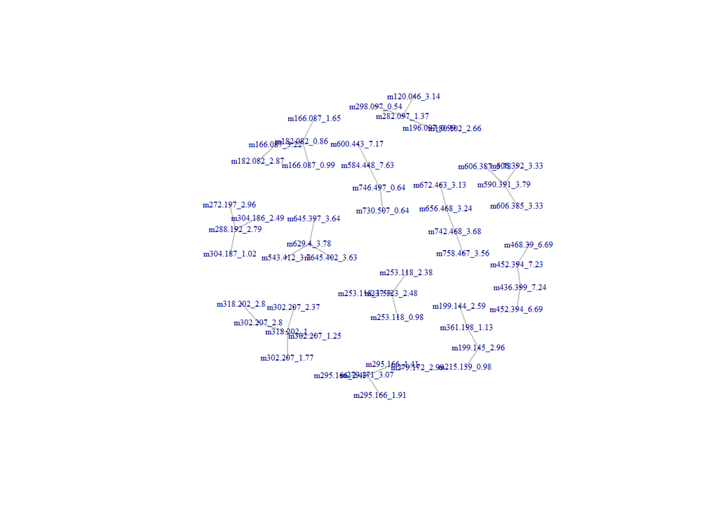

```r
adj <- assay(comb_adj, "combine_binary")
g_comp <- graph_from_adjacency_matrix(adj, mode = "undirected") %>%
    components()
inds <- g_comp$membership %in% which(g_comp$csize > 3)

## create a graph from the cut adjacency matrix
g <- graph_from_adjacency_matrix(adj[inds, inds], mode = "undirected")

## finally plot the graph
plot(g, edge.width = 1, vertex.label.cex = 0.5, vertex.size = 0.5,
     edge.color = "grey")
```